# trial-b fit overview

Pawel Sadlowski

# Thresholds

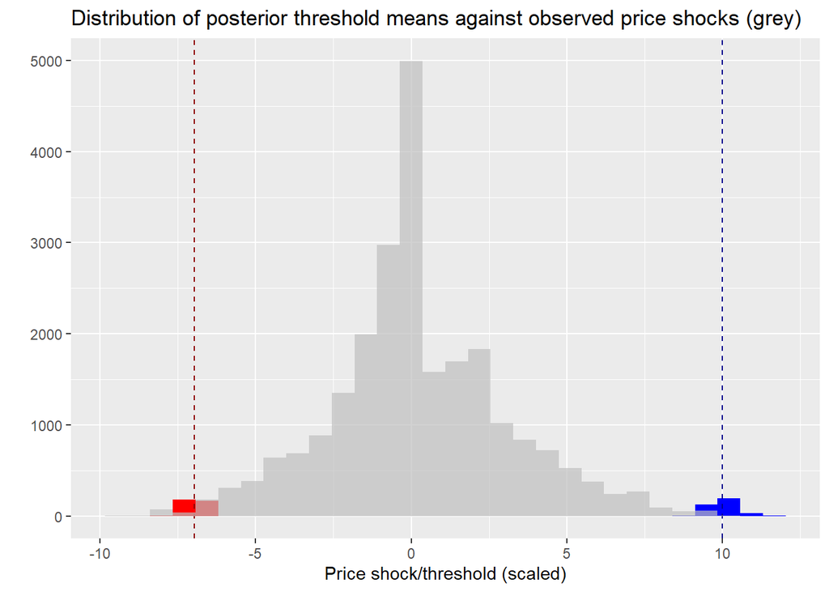

```r
ggplot( data.frame(
  lower = apply( posterior[,,grep( 'r_lower', dimnames( posterior)[[3]])], 3, mean),
  upper = apply( posterior[,,grep( 'r_upper', dimnames( posterior)[[3]])], 3, mean))) +
  geom_histogram( aes( x = lower), fill = 'red') +
  geom_histogram( aes( x = upper), fill = 'blue') +
  geom_vline( xintercept = mean( posterior[,,grep( 'r_lower', dimnames( posterior)[[3]])]),
              color = 'darkred', linetype = 'dashed') +
  geom_vline( xintercept = mean( posterior[,,grep( 'r_upper', dimnames( posterior)[[3]])]),
              color = 'darkblue', linetype = 'dashed') +
  geom_histogram( data = data.frame( ps = as.vector( d$ps)), aes( x = ps), fill = 'grey',
                  alpha = 0.7) +
  ggtitle( 'Distribution of posterior threshold means against observed price shocks (grey)') +
  xlab( 'Price shock/threshold (scaled)') + ylab( '')
```

All the purchases essentially fall into the LPA. This might be either the feature of the gamma prior on threshold variance (which is, however, effectively shrunk) or some artifacts in the data (e.g. low obs counts)

# Threshold regression

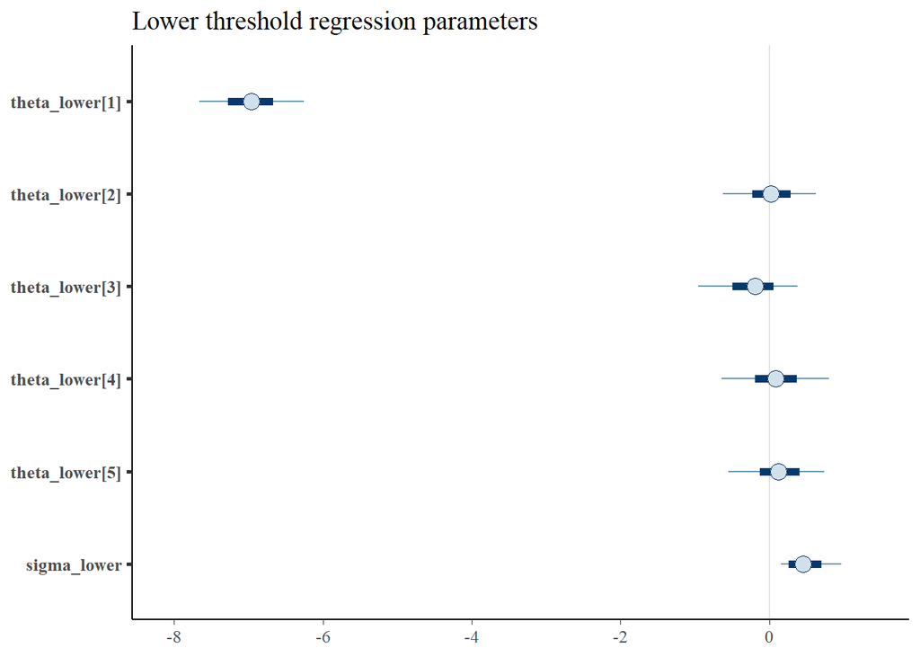

```r
mcmc_intervals( posterior[,,c( grep( 'theta_lower', dimnames( posterior)[[3]], value = T),
                               'sigma_lower')]) +
  ggtitle( 'Lower threshold regression parameters')
```

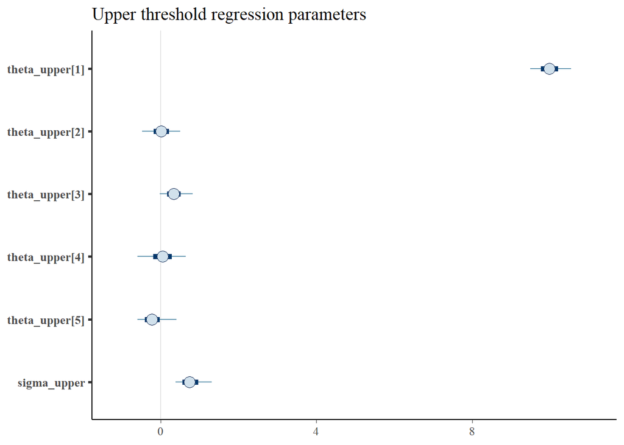

```r
mcmc_intervals( posterior[,,c( grep( 'theta_upper', dimnames( posterior)[[3]], value = T),
                               'sigma_upper')]) +
  ggtitle( 'Upper threshold regression parameters')
```

Only the intercept is meaningfully nonzero in this setting

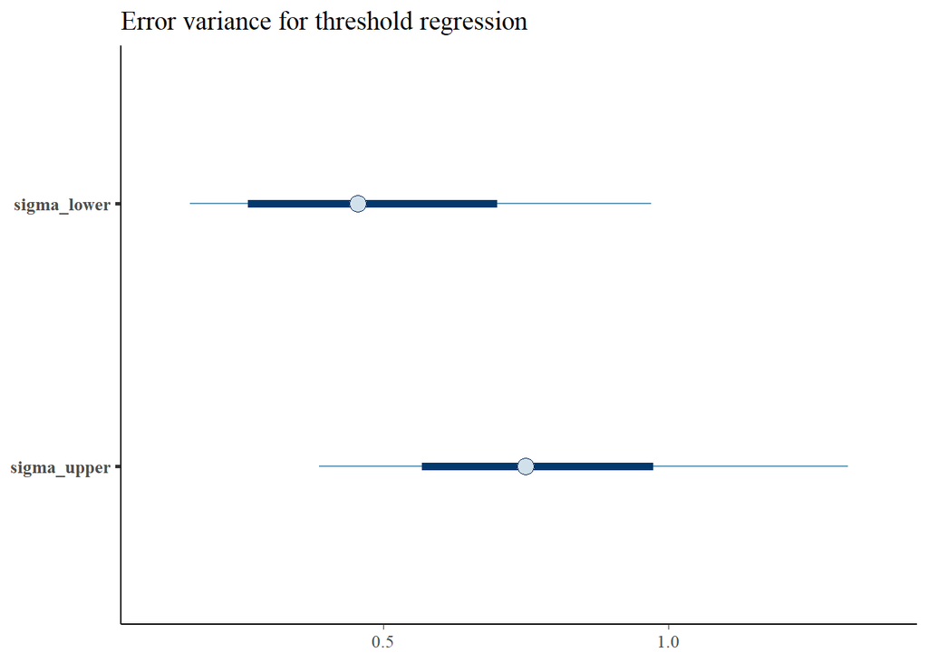

```r
mcmc_intervals( posterior[,,c( 'sigma_lower', 'sigma_upper')]) +
  ggtitle( 'Error variance for threshold regression')
```

Threshold variances are similar in magnitude.

# Product choice regression

## Price elasticity

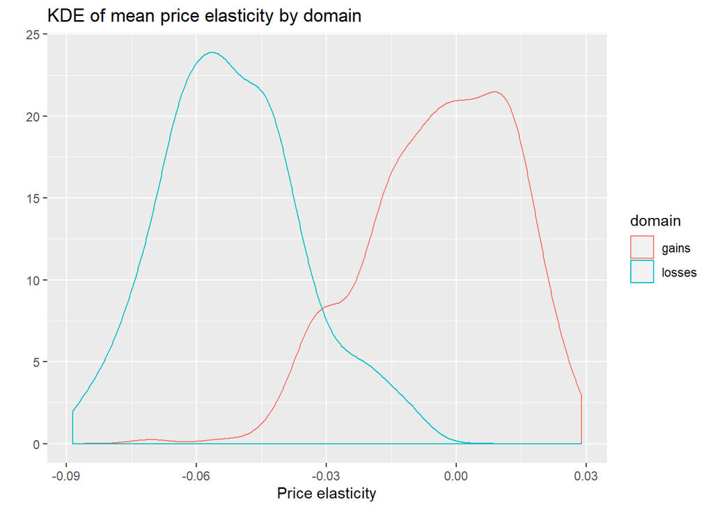

```r
# ggplot(
#   apply( posterior[,,grep( paste0( 'beta_((gains)|(lpa)|(losses))\\[\\d+,', d$K, '\\]'),
#                            dimnames( posterior)[[3]], value = T)],
#          3, mean) %>% data.frame(
#            val = .,
#            domain = regmatches( names( .), regexpr( '(gains)|(lpa)|(losses)', names( .))))) +
#   geom_density( aes( x = val, color = domain)) +
#   ggtitle( 'KDE of mean price elasticity by domain') +
#   xlab( 'Price elasticity') + ylab( '')

# LPA now excluded due to the constraint
ggplot(
  apply( posterior[,,grep( paste0( 'beta_((gains)|(losses))\\[\\d+,', d$K, '\\]'),
                           dimnames( posterior)[[3]], value = T)],
         3, mean) %>% data.frame(
           val = .,
           domain = regmatches( names( .), regexpr( '(gains)|(losses)', names( .))))) +
  geom_density( aes( x = val, color = domain)) +
  ggtitle( 'KDE of mean price elasticity by domain') +
  xlab( 'Price elasticity') + ylab( '')
```

Price elasticity is small (negative, as expected) in the losses domain and zero in gains.

## Product-specific intercepts

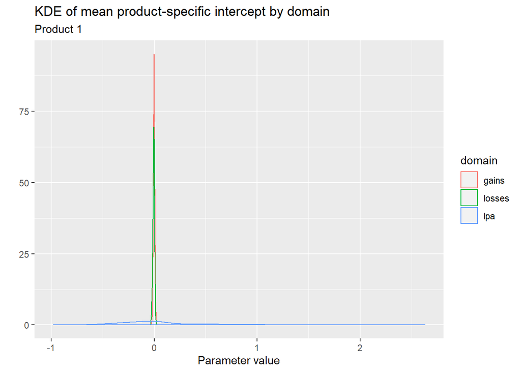

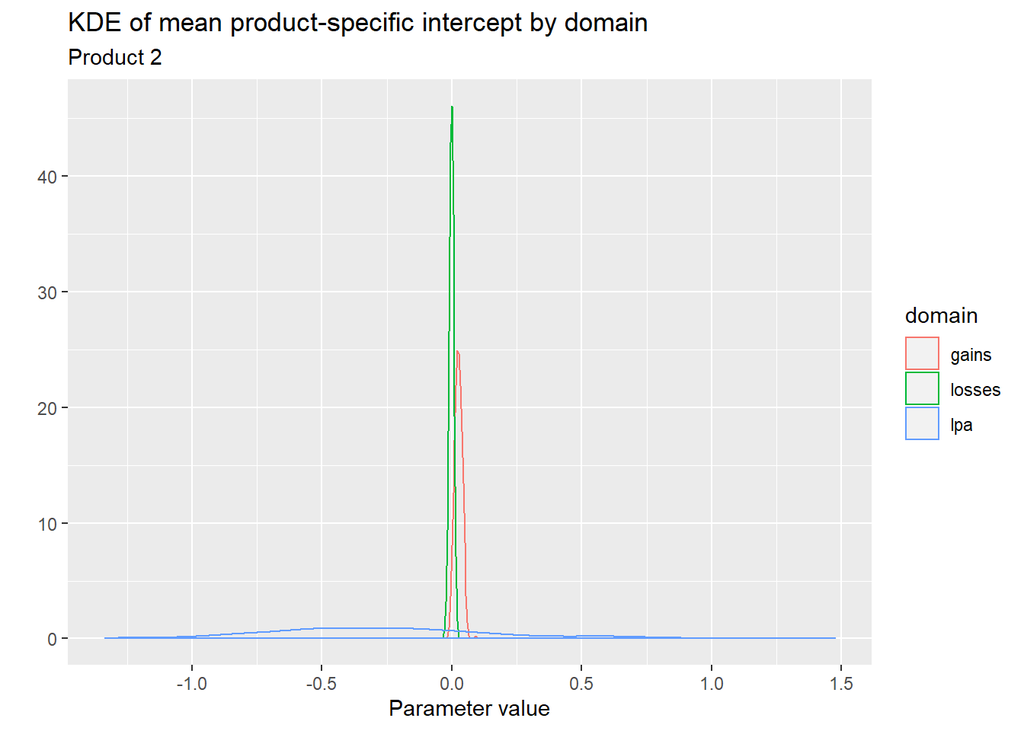

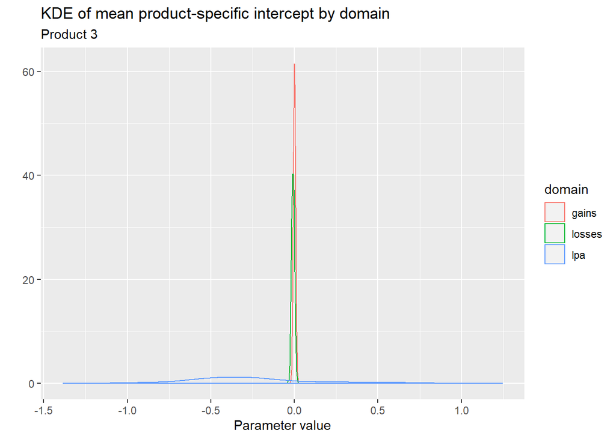

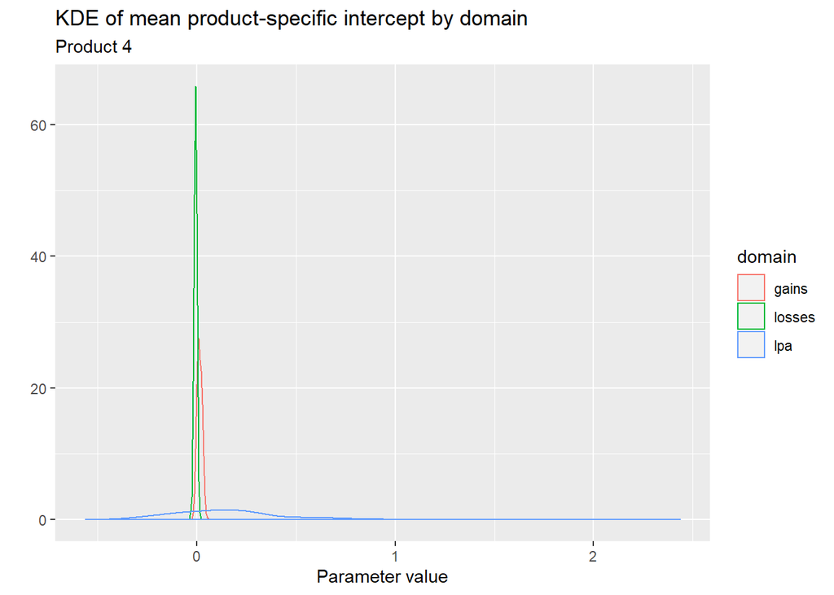

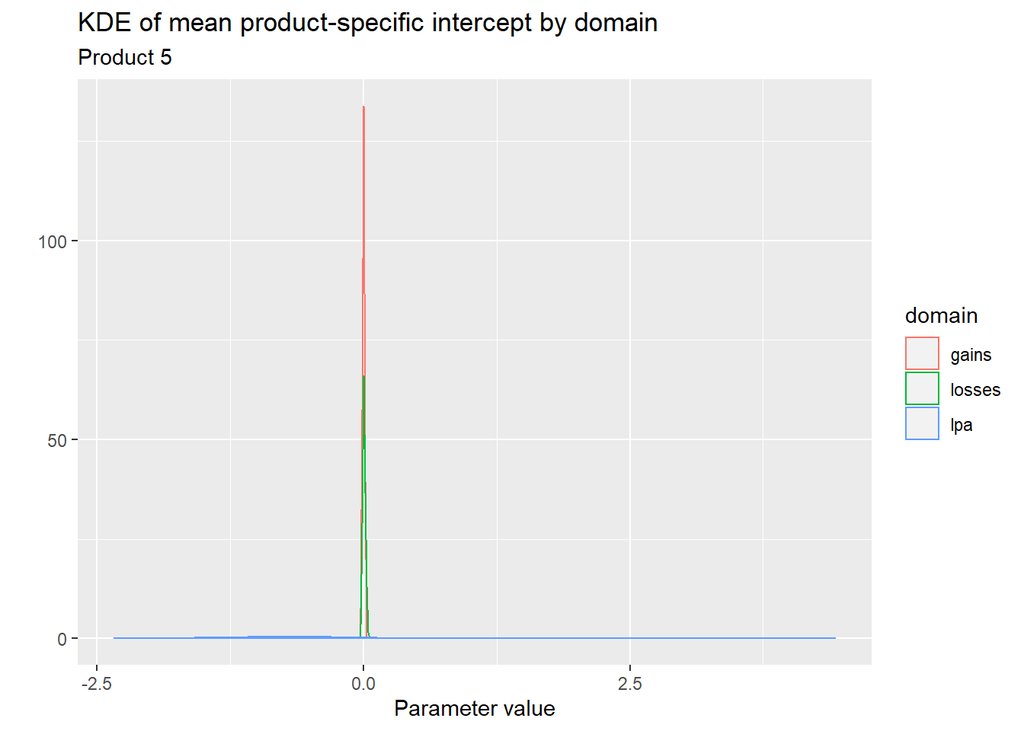

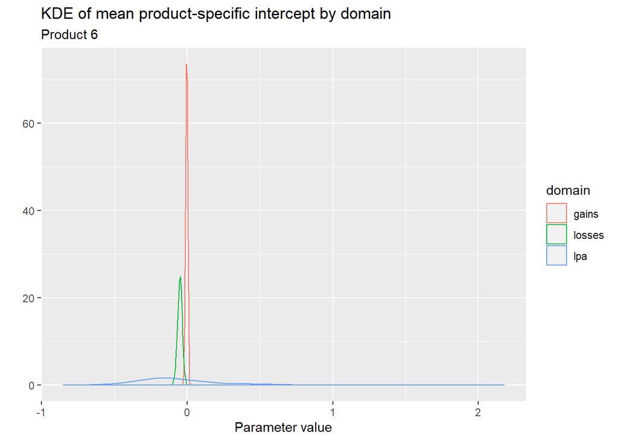

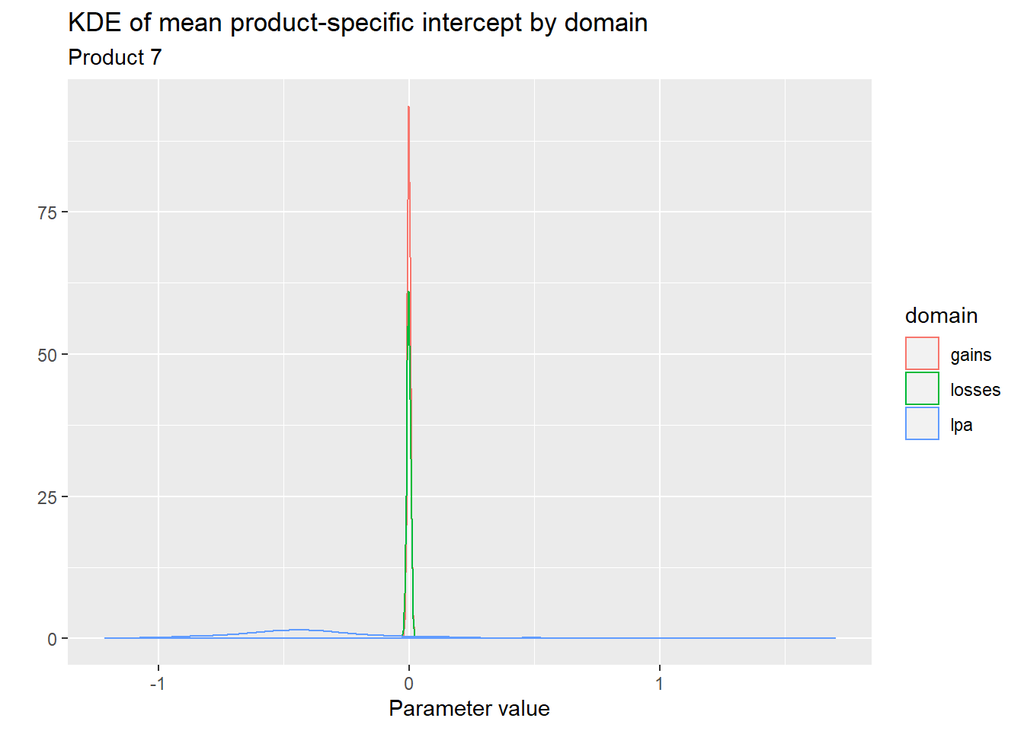

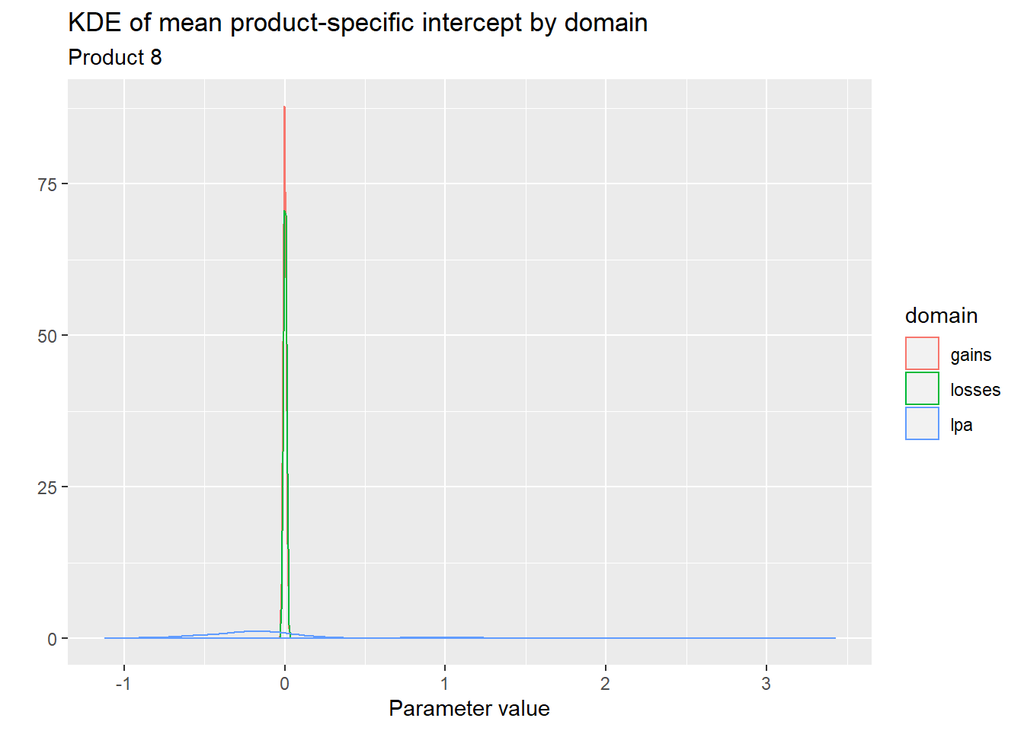

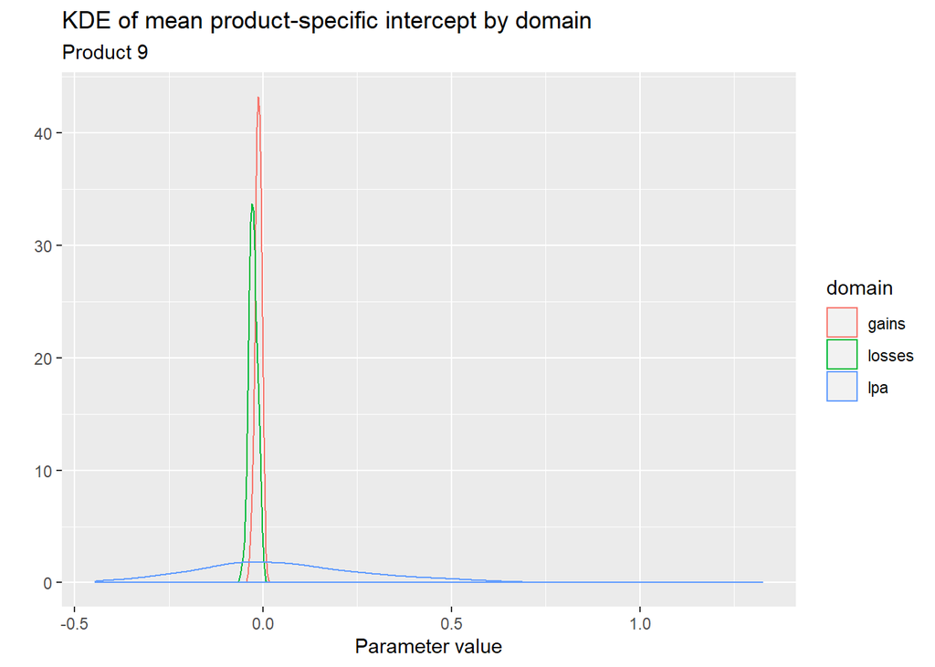

```r
lapply( 1:d$M, function( ii) {
  ggplot(
    apply( posterior[,,grep( paste0( 'beta_((gains)|(lpa)|(losses))\\[\\d+,', ii, '\\]'),
                             dimnames( posterior)[[3]], value = T)],
           3, mean) %>% data.frame(
             val = .,
             domain = regmatches( names( .), regexpr( '(gains)|(lpa)|(losses)', names( .))))) +
    geom_density( aes( x = val, color = domain)) +
    ggtitle( 'KDE of mean product-specific intercept by domain',
             sub = sprintf( 'Product %i', ii)) +
    xlab( 'Parameter value') + ylab( '')
})
```

Preferences for products only visible in the LPA domain (the only observed domain, actually)

## Remaining regression parameters

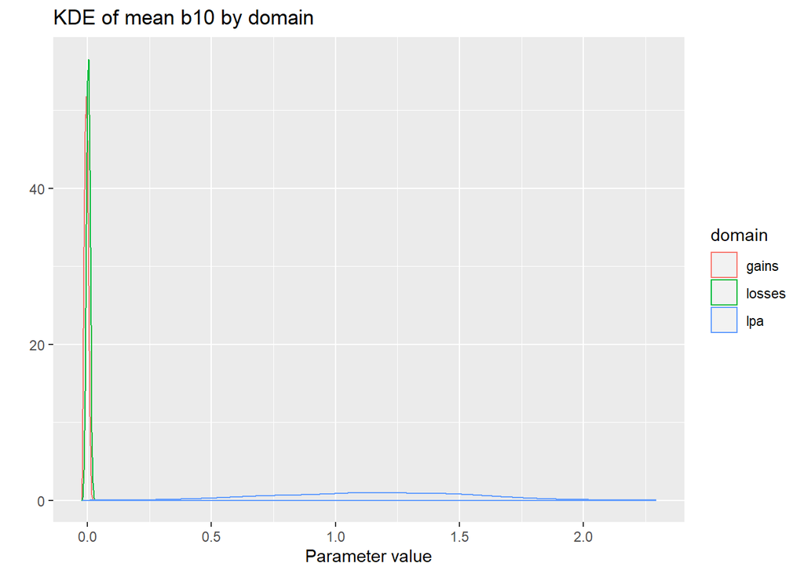

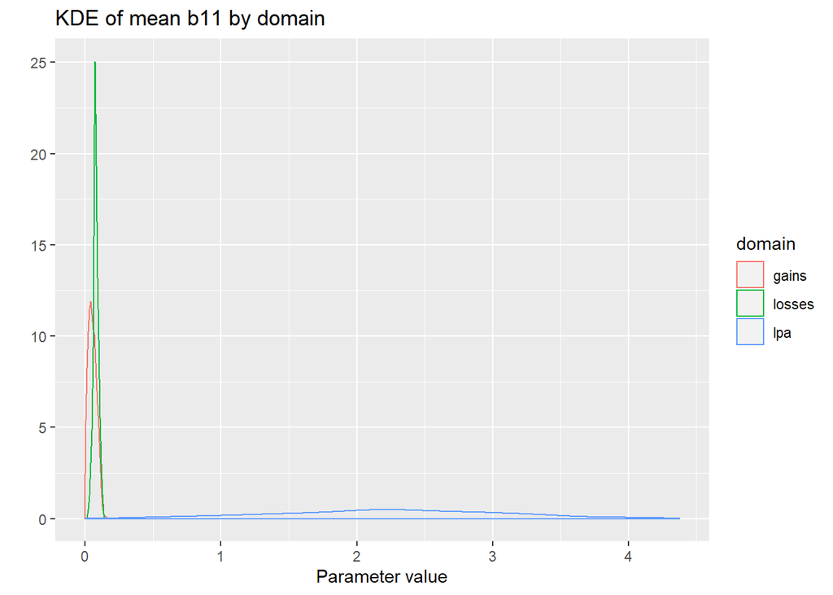

```r
lapply( (d$M+1):(d$K-1), function( ii) {
  ggplot(
  apply( posterior[,,grep( paste0( 'beta_((gains)|(lpa)|(losses))\\[\\d+,', ii, '\\]'),
                           dimnames( posterior)[[3]], value = T)],
         3, mean) %>% data.frame(
           val = .,
           domain = regmatches( names( .), regexpr( '(gains)|(lpa)|(losses)', names( .))))) +
  geom_density( aes( x = val, color = domain)) +
  ggtitle( sprintf( 'KDE of mean b%i by domain', ii)) +
  xlab( 'Parameter value') + ylab( '')

})
```

$\beta_{10}$ (display/feature) is clearly positive

$\beta_{11}$ (brand loyalty) is clearly positive as well and the effect is stronger.

# Beta regressions

## Price elasticity

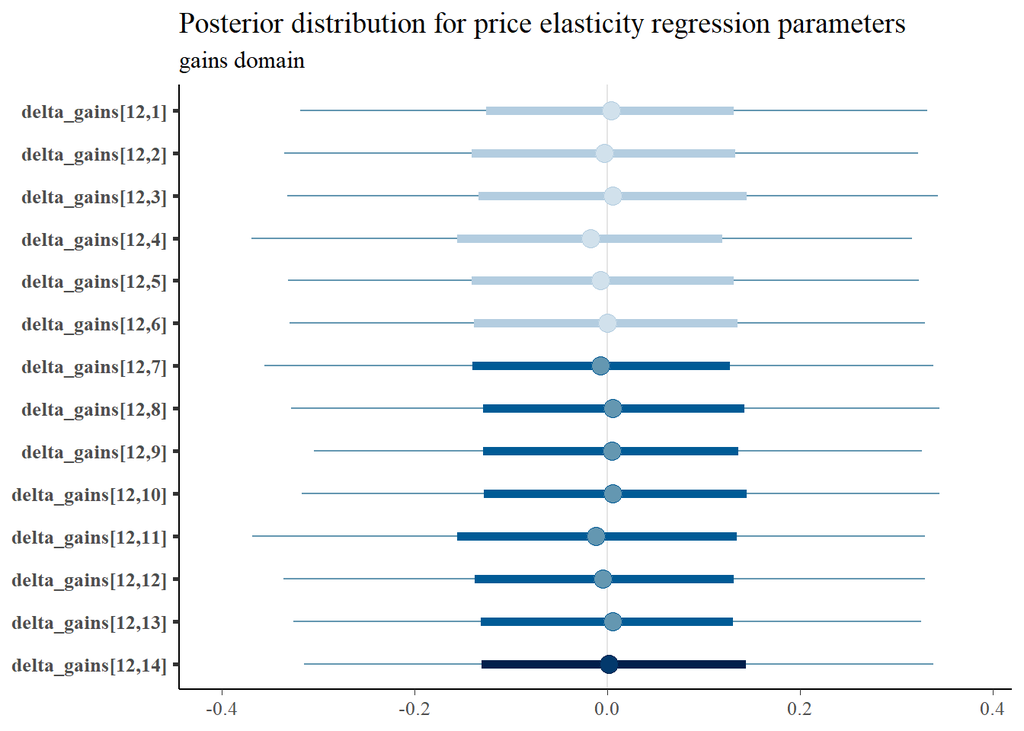

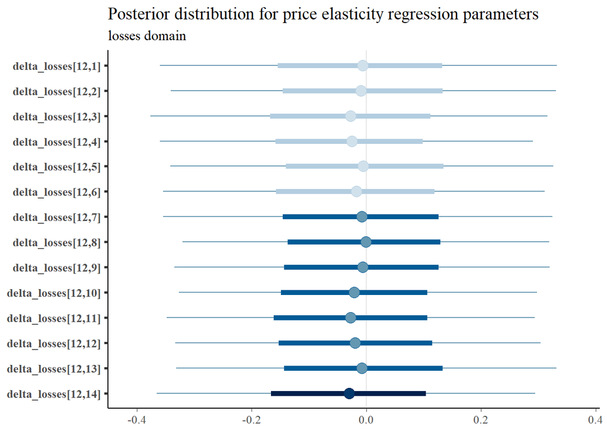

```r
lapply( c( 'gains', 'losses'),
        function( domain) {
          mcmc_intervals( posterior[,,grep( paste0( 'delta_', domain, '\\[', d$K, ',\\d+\\]'),
                                            dimnames( posterior)[[3]], value = T)],
                          rhat = c( rep( 1, 6), rep( 1.06, 7), 1.2)) +
            ggtitle( 'Posterior distribution for price elasticity regression parameters',
                     sub = paste0( domain, ' domain')) + legend_none()
        })
```

Gains/losses domains are almost nonextistent so no wonder that no clear effects were spotted.

## Remaining parameters

```r
lapply( 1:(d$K-1),
        function( ii) {
          lapply( c( 'gains', 'lpa', 'losses'),
        function( domain) {
          mcmc_intervals( posterior[,,grep( paste0( 'delta_', domain, '\\[', ii, ',\\d+\\]'),
                                            dimnames( posterior)[[3]], value = T)],
                          rhat = c( rep( 1, 6), rep( 1.06, 7), 1.2)) +
            ggtitle( sprintf( 'Posterior distribution for beta %i regression parameter', ii),
                     sub = paste0( domain, ' domain')) + legend_none()
        })
        })
```

```
## [[1]]
## [[1]][[1]]
```

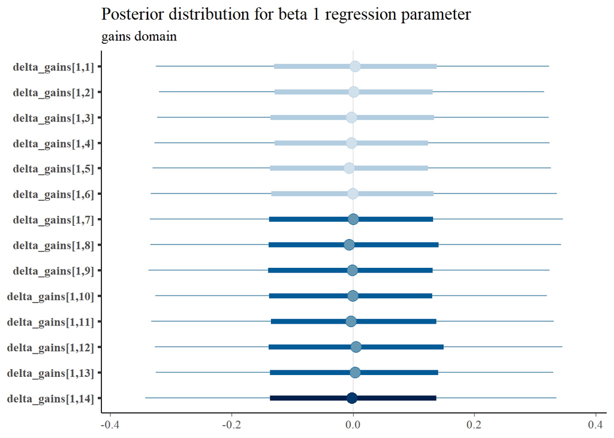

```
##
## [[1]][[2]]
```

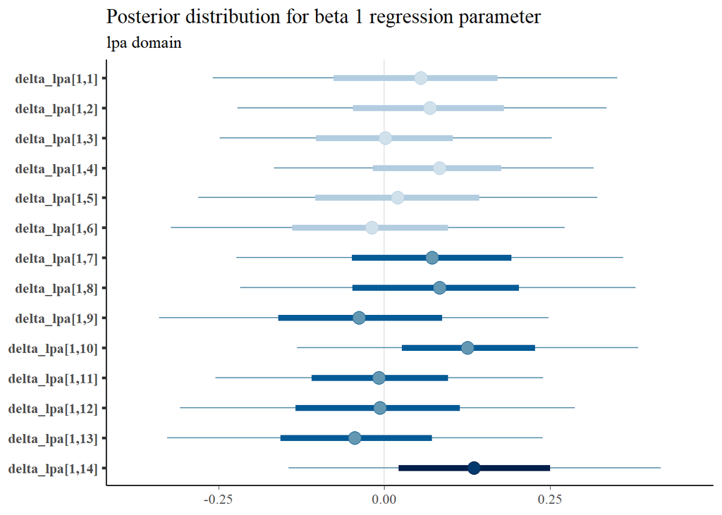

```
##
## [[1]][[3]]
```

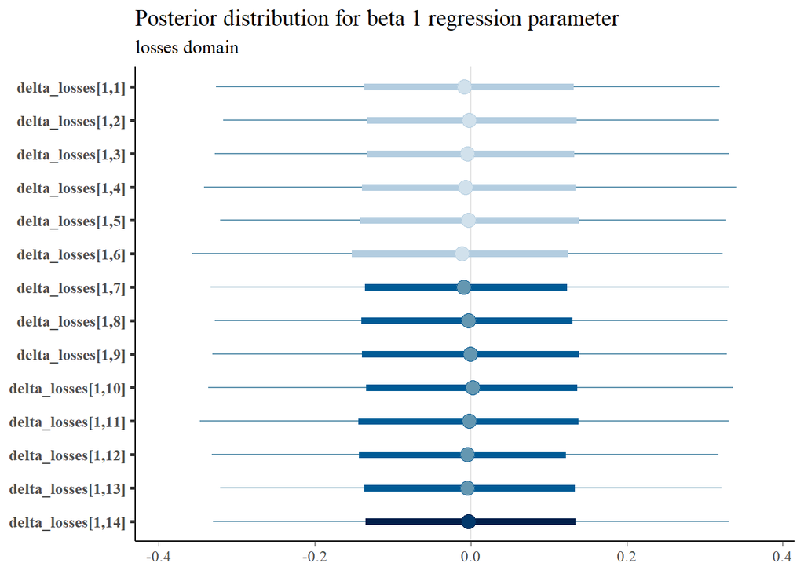

```
##
##
## [[2]]
## [[2]][[1]]
```

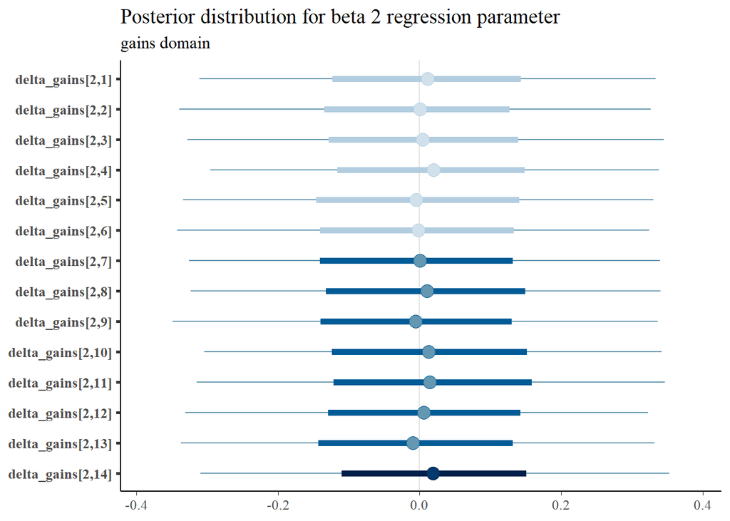

```
##
## [[2]][[2]]
```

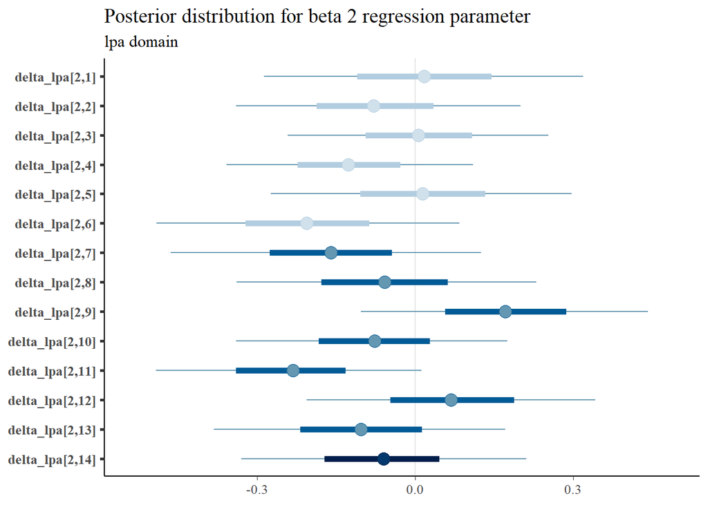

```
##
## [[2]][[3]]
```

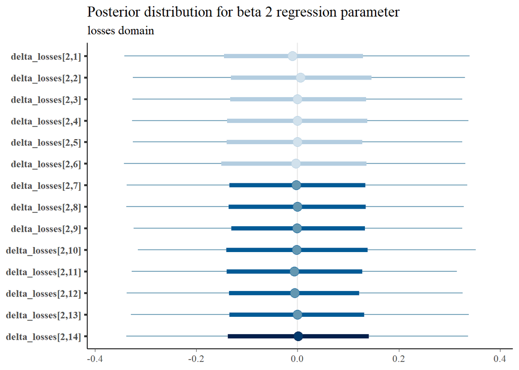

```
##
##
## [[3]]
## [[3]][[1]]
```

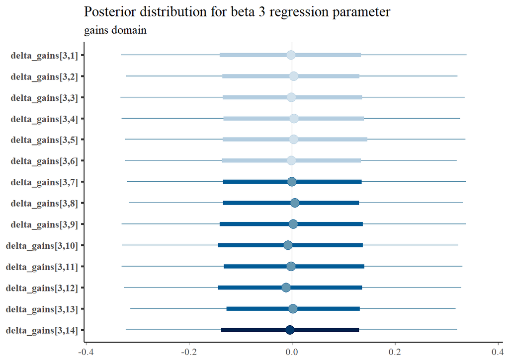

```
##
## [[3]][[2]]
```

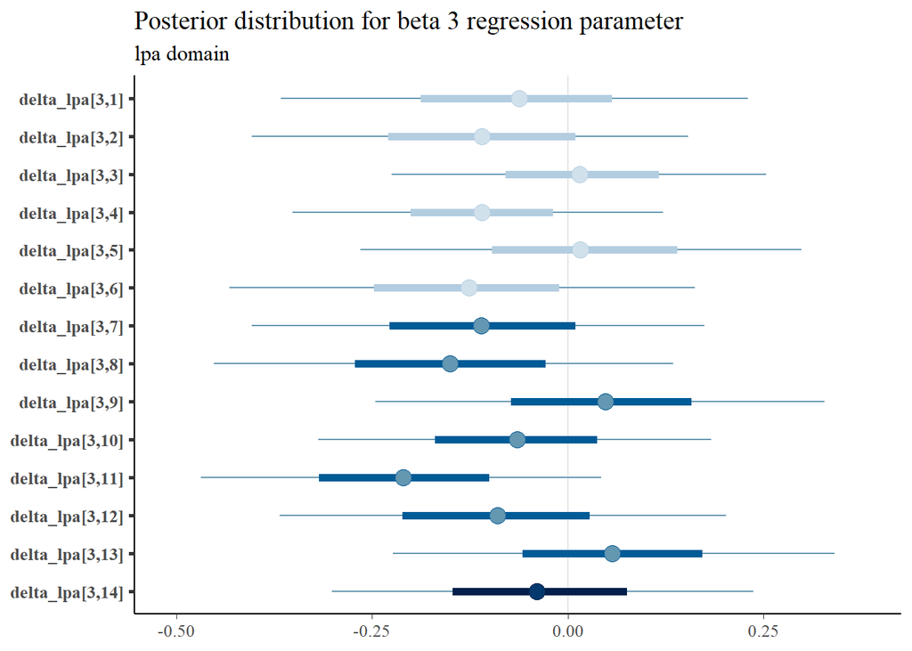

```
##
## [[3]][[3]]
```

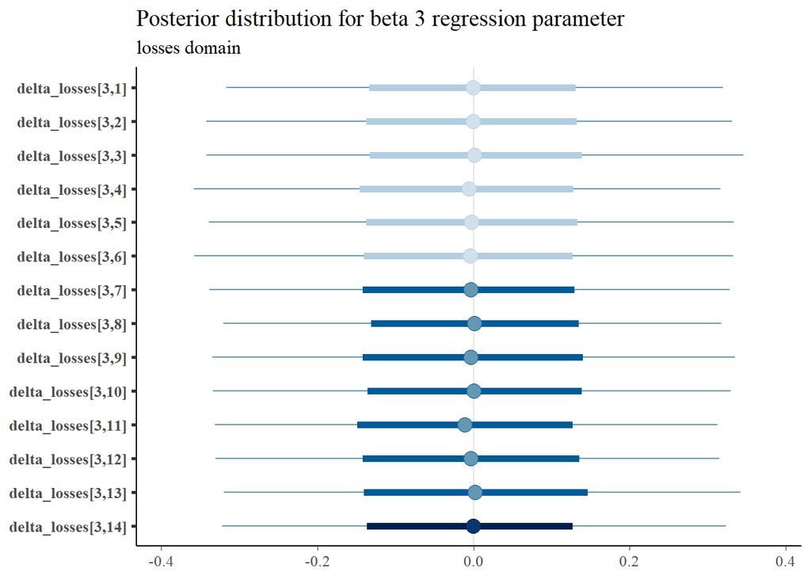

```
##
##
## [[4]]
## [[4]][[1]]
```

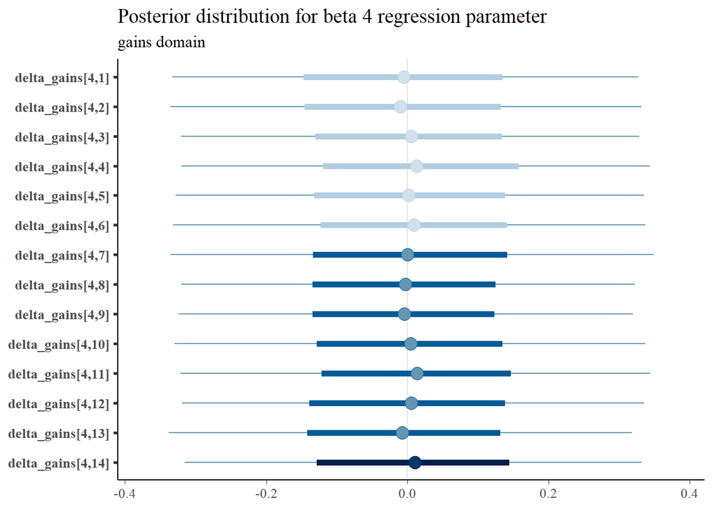

```
##
## [[4]][[2]]
```

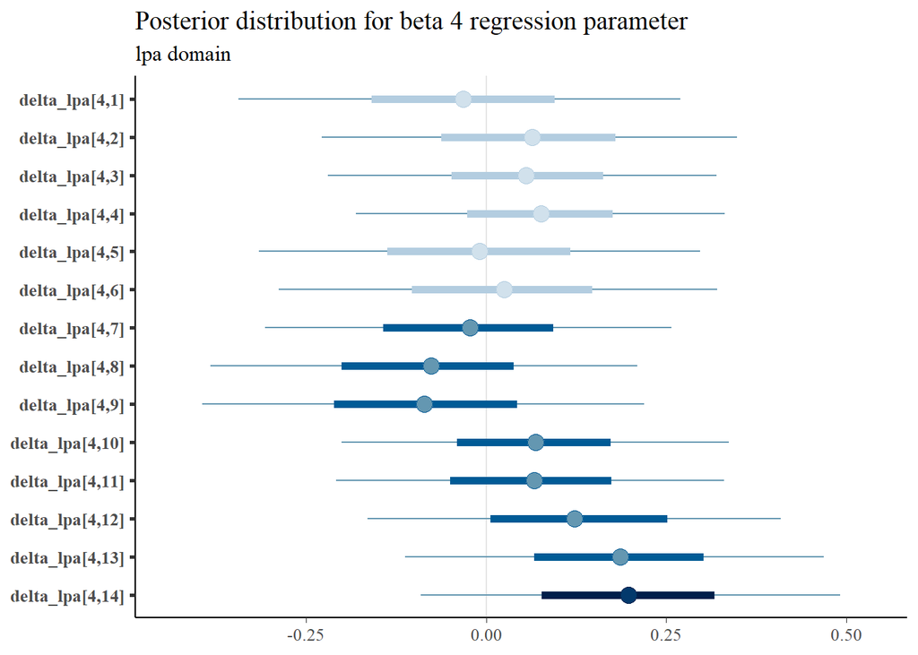

```
##
## [[4]][[3]]
```

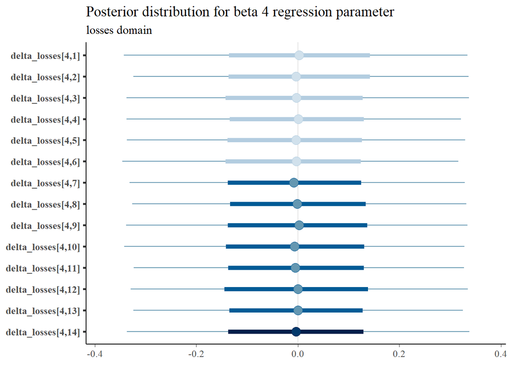

```
##
##
## [[5]]
## [[5]][[1]]
```